# volume 9 number 2 – Page 5 – The Sport Journal

Skip to content

ISSN: 1543-9518|Vol. 24

## [Relationship of Selected Pre–NBA Career Variables to NBA Players’ Career Longevity](https://thesportjournal.org/article/relationship-of-selected-pre-nba-career-variables-to-nba-players-career-longevity/)

Submitted by: William Abrams, East Lansing, Michigan,  
John C. Barnes, University of New Mexico,  
Annie Clement, Ph. D., J.D., Saint Leo University

Abstract

Given the change in the business nature of the National Basketball Association (NBA), the player evaluation process has become increasingly important. The methods discussed in this article can aid general managers and owners in the player acquisition process by providing a means of evaluating talent. The purpose of the study was to identify the relationship between pre–NBA career statistical variables and career longevity, measured as the number of seasons in the NBA. Data from the 1988–2002 collegiate basketball seasons were analyzed. Participants consisted of 329 NBA guards, forwards, and centers who entered the NBA in 1988 and ended their careers during or before the 2002 NBA season. The study included 11 independent variables: points, rebounds, assists, steals, blocks, fouls, turnovers, minutes played, free throw percentage, field goal percentage, and 3 point percentage. There was a single dependent variable, career longevity. Data analysis comprised multiple regression tests to determine the relationship between the independent variables and the dependent variable. The multiple regression tests revealed a relationship between pre-career statistical variables and career longevity for guards and forwards. However, no such relationship was found for centers.

Introduction

The National Basketball Association (NBA) is a multimillion-dollar professional sport business. The value of team franchises has grown dramatically since David Stern became NBA commissioner in 1984. That season, the average team value was around $15 million (Smith, 2003). The figure had risen to around $300 million by 2003 (Smith, 2003). The increased revenues in the game have led to higher player salaries, which mean more pressure on individual players to perform. The business nature of basketball has put a premium on the selection of players and on the process—an imprecise science—that goes into selection. Owners and general managers are desiring to operate their teams according to corporate models, by controlling escalating player salaries (Sandoval, 2003). Front-office executives want to reduce the risk of bad draft picks and overpaid free agents (Sandoval, 2003).

Given the financial structure and business nature of the game, how do general managers and owners measure and evaluate a player’s potential for success? Additionally, how do they make personnel decisions in a league in which the stakes are so high that one bad decision can make for disaster in the form of millions of dollars lost? One important aspect of building a championship NBA team is how the general manager constructs the team roster. It is expected that the general manager will attempt to acquire the most talented players when building a team (Staw & Hoang, 1995). How to accomplish this is the problem that owners and general managers continually face. Berri (1999) stated that, “[W]ithout an answer, one is unable to ascertain who should play, what free agents should be pursued, or what trades should be consummated” (p. 411).

In the current era of professional basketball, with the average player salary reaching over $5 million, owners want to operate their businesses more efficiently by controlling costs and risks (Sandoval, 2003). The goal is to reduce the number of bad draft picks and avoid signing the least productive players (Sandoval, 2003).

The evaluation of potential playing talent is a difficult task (Berri & Brook, 1999). In professional basketball, using selected statistical variables to measure a player’s prospective success is considered an important part of the player evaluation process (Berri & Brook, 1999). Assembling players who produce at statistically high levels may ultimately improve a team. Berri (1999) identified a link between player statistics and team wins. The NBA draft is one of the primary methods by which teams acquire talent. Staw & Hoang (1995) found that the order in which players were drafted correlated with their playing time and the length of their careers.

The NBA draft’s importance becomes even clearer when one considers how the draft inevitably represents a set of lost opportunities (Staw & Hoang, 1995). In selecting any one particular player, a team may be passing over the next all-star or superstar player (Staw & Hoang, 1995). The NBA draft is thus very risky (Amico, 2001). History has shown that the projection of player development is not a precise science, and that teams may be in need of effective evaluative methods when scouting talent (Amico, 2001). The risks of the draft were made widely known by the Portland Trail Blazers when, in 1984, that team anticipated greater benefits from signing Sam Bowie than from signing Michael Jordan. And in the same draft, Dallas selected Sam Perkins and Terrance Stansbury instead of Auburn University’s Charles Barkley and Gonzaga University’s John Stockton (Staw & Hoang, 1995). Selection of the right players through the NBA draft is important (Staw & Hoang, 1995).

The NBA draft used to require relatively little work or resources (Shouler, Ryan, Koppett, & Bellotti, 2004). Teams had small scouting staffs to evaluate college players, yet by the time the draft came around, every team knew who the best players were and which ones they wanted to draft (Shouler et al., 2004). As basketball became more of a business, general managers, owners, and team presidents had to change their approach. Even as the process changed, however, the goal stayed the same (Popper, 2004). It is to improve the team through selection of the best, most valuable player available at the time a team is making a selection (Popper, 2004).

Currently, there is no known research that looks to pre-career statistical data to determine longevity of NBA play (although, again, NBA experts view potential career longevity as an important factor characterizing NBA draft prospects, according to Amico, 2001). Those studies that are available did not examine relationships between predictor variables and career longevity. According to Oliver (2005), the value of individual NBA players can be assessed using traditional statistical categories. Previous studies looked at the statistics for NBA players recorded during their play in the league; they sought to identify alternative methods of evaluating talent (Ballard, 2005). The success of the NBA players was measured using the traditional statistical categories (points, rebounds, field goals attempted, field goals made, etc.) (Ballard, 2005). Thus while most of these studies obtained traditional player statistics, they did not go on to look for relationships between those statistics and the players’ career longevity (i.e., number of seasons in the NBA). Some research, however, indicates that there is a positive relationship between traditional player statistics and the length of NBA players’ careers (Staw & Hoang, 1995).

Major League Baseball was the first league to experiment with statistical predictor models. Specifically, the Oakland Athletics’ general manager began to evaluate talent primarily by looking at player statistics, and he both drafted players and acquired free agents based on this nontraditional method (Lewis, 2003). This method of evaluation became known as the money ball theory, reflecting its capacity to identify productive players available at below-market value, whom traditional scouting methods would not view as commodities (Lewis, 2003). Money ball theory has proved a success for the Oakland Athletics and for another team that uses statistical methods to evaluate talent: the Boston Red Sox.

The reasoning underlying the use of player statistics in professional baseball is rooted in the idea that college players generate meaningful statistics (Lewis, 2003). College players play more games than high school players, and the level of competition is enhanced at the collegiate level as opposed to the high school level (Lewis, 2003). Collegiate statistics, then, reflect a sample size large enough to accurately picture the underlying reality (Lewis, 2003). Projecting the ongoing success of college players is thus easier than making such projections for high school players (Lewis, 2003).

The statistics that can be garnered from college play enable baseball executives and scouts to see past all kinds of visual scouting prejudices (Lewis, 2003). Indeed, it has been argued that what is most important about a baseball player is not the player’s character but the picture drawn by his statistics (Lewis, 2003).The belief of experts who employ predictor statistics in baseball is that a player “is” what he has already done, not what he looks like or might become (Lewis, 2003). It is a belief that runs counter to the thinking of the traditional baseball scout, to whom what matters is what the scout can envision the player doing (Lewis, 2003).

The concept of statistical analysis of talent in baseball was brought to bear on efforts to make the development of players more efficient. As Lewis (2003) stated, the statistics used to evaluate baseball players were probably far more accurate than anything used to measure the value of people who didn’t play baseball for a living. Adding a statistical model to traditional scouting and player evaluation methods can better inform owners and general managers about talent, permitting them to identify skill sets related to career longevity. In basketball, too, better gauging of players’ potential success may lead to a more efficient process of putting together an NBA team roster.

Method

The purpose of the study was to identify the relationship between selected pre–NBA career statistical variables and NBA players’ career longevity (measured as the number of seasons in the NBA). Specifically, the following two questions were addressed:

1. Can 1 or more of the 11 traditional player statistics, recorded during the year preceding entry into the NBA, predict the career longevity of NBA guards, NBA forwards, and NBA centers?
2. Can 1 or more of the 11 traditional player statistics, recorded during the 2 years preceding entry into the NBA, predict the career longevity of NBA guards, NBA forwards, and NBA centers?

The study questions were built around 1-year and 2-year collegiate statistics on the assumption that performance during these specific periods is the best indicator of NBA potential. This is assumed because, statistically speaking, it is during these periods that college players who subsequently entered the NBA played their best collegiate seasons.

Data Collection

The particular statistics chosen for the present study’s multiple regressions were based on the history of players’ statistical production at the position of guard, of forward, and of center. Historical statistical production by guards, forwards, and centers in the 11 basketball activities thus provided the basis for the present analysis. Over the history of basketball, the players occupying the three positions produced proficiently in those statistical areas which the present study has associated with each position, as follows: (a) guards—field goal percentage, 3 point percentage, free throw percentage, assists, steals, turnovers, points, personal fouls, and minutes played; (b) forwards—rebounds, 3 point percentage, points, free throw percentage, steals, blocks, field goal percentage, turnovers, personal fouls, assists, and minutes played; and (c) centers—rebounds, free throw percentage, field goal percentage, blocks, personal fouls, turnovers, points, and minutes played.

The statistics themselves were obtained from an unofficial professional and collegiate basketball website, Database Basketball (located at http://www.databasebasketball.com). Database Basketball is a primary Internet resource for gathering players’ statistical data at both levels. It houses information on all college players who played in the NBA and on those who were NBA draft picks. The website also provided for the study the total number of players playing in the NBA from 1987–88 to 2001–02. The study employed the collegiate statistics from the year immediately preceding a study participant’s entry into the NBA.

Participants

The present study included 329 players who entered the NBA during or after the 1987–88 and ended their playing careers with the 2001–02 season or earlier; the study excluded players who entered the NBA directly from high school, directly from junior college, or from an overseas league. The sample was furthermore limited to NBA athletes who had played at NCAA member institutions for at least two seasons. The time frame 1987–88 to 2001–02 was deemed recent enough to be relevant to the present; it also included enough time to obtain a representative number of players for study. Beyond the specified time frame and the exclusion of players lacking an NCAA collegiate record or transferring from overseas leagues, study participants had to have played in at least one NBA game. Those players who entered in the 1987–1988 season were the most relevant sample, because of changes marked that season in both the NBA style of play and its draft structure. The latter change led NBA general managers to try new and different draft strategies than in years past.

Design and Analysis

The data were analyzed using SPSS (Version 12.0). A multiple linear regression analysis was conducted involving the dependent variable, career longevity, and 2 or more of the 11 criterion variables. Multiple regression analysis was used in order to find the variable or combination of variables yielding the most accurate prediction of NBA career longevity (Thomas & Nelson, 2001). Multiple regression analysis made it possible to combine the variables from collegiate statistics to produce optimal assessment of their relationship with the independent variable, NBA career longevity (Allison, 1999). Alpha level for the analyses was set at p < 0.05.

Six multiple regressions were conducted to assess the relationship between pre–NBA career statistical variables and NBA career longevity. Each of the regressions conducted was based on player position, with guard, forward, and center positions being analyzed. In three regressions (one per position), the 2-year collegiate statistics (statistics for the two college seasons immediately prior to the player’s entering the NBA) constituted the independent variables; in the remaining three regressions (one per position), the 1-year collegiate statistics (statistics for the college season immediately preceding NBA entry) constituted the independent variables. Career longevity (i.e., number of seasons in the NBA) was the outcome variable in all of the regression analyses.

Results

Of the 329 NBA players included in this study, 133 were listed as guards, 142 were forwards, and 54 were centers. The average length of their NBA careers was 4.81 seasons (SD = 3.69).

1-Year Statistics

A significant (p < .05) overall regression was found for guards during analysis of the 1-year statistics (F = 3.218), with an R of .437. The individual statistics measuring assists, turnovers, and points had significant beta scores (Table 1).

Table 1

Summary of Regression Analysis for one-year statistics for guards prior to entry into the  
NBA.

| Variable | B | SE B | β |
| --- | --- | --- | --- |
| (Constant) | 4.106 | 4.266 |  |
| FGP | -.703 | .935 | .063 |
| TPP | 1.188 | .018 | .195 |
| FTHP | -6.033 | 5.113 | -1.180 |
| ASST | 0.02151* | .008 | .362 |
| STEAL | 0.02025 | .017 | .124 |
| TURN | -0.03933* | .019 | -.237 |
| POINT | 0.009410* | 003 | ..386 |
| PF | -0.01436 | .020 | -.065 |
| MIN | -0.00006548 | .000 | -.015 |

*p <.05

A significant (p < .05) overall regression was also found for the NBA forwards during analysis of the 1-year statistics (F = 2.531), with an R of .449. Field goal percentage, free throw percentage, and assists had significant beta scores within the equation (Table 2). For the 1-year totals for the center position, neither overall significance nor significant beta scores were found.

Table 2

Summary of Regression Analysis for one-year statistics for forwards prior to entry into the NBA.

| Variable | B | SE B | β |
| --- | --- | --- | --- |
| (Constant) | -12.424 | 4.971 |  |
| REB | 0.006540 | .006 | .130 |
| TPP | 1.954 | 1.347 | .136 |
| POINT | -0.0004532 | .001 | -.069 |
| FTHP | 7.629* | 4.227 | .169 |
| STEAL | 0.03883 | .025 | .174 |
| BLOCK | 0.006794 | .013 | .050 |
| FGP | 20.291* | 6.800 | .300 |
| TURN | -0.01215 | .020 | -.073 |
| PF | -0.006445 | .021 | -0.33 |
| ASST | 0.03073* | .014 | .270 |
| MIN | -0.002766 | .002 | -.143 |

*p <.05.

2-Year Statistics

In the three multiple regressions run using the 2-year statistics (combined totals), a significant (p < .05) overall regression was found for guards (F = 3.706), with an R of .462. Assists, steals, turnovers, and points generated significant scores during the analysis (Table 3).

Table 3  
Summary of Regression Analysis for two-year statistics for guards prior to entry into the NBA.

Coefficients Table

| Variable | B | SE B | β |
| --- | --- | --- | --- |
| (Constant) | -3.726 | 5.370 |  |
| FGP | 10.914 | 6.844 | .140 |
| TPP | 1.954 | 1.347 | .136 |
| FTHP | -4.098 | 5.764 | -.070 |
| ASST | 0.01140* | .005 | .340 |
| STEAL | 0.01725* | .010 | .193 |
| TURN | -0.02513* | .012 | -.255 |
| POINT | 0.004940* | .002 | .351 |
| PF | 0.001047 | .011 | .009 |
| MIN | 0.0001264 | .000 | .031 |

*p <.05.

Coefficients Table

| Variable | B | SE B | β |
| --- | --- | --- | --- |
| (Constant) | 1.216 | 2.703 |  |
| REB | 0.007322* | .004 | .257 |
| TPP | 1.954 | 1.347 | .136 |
| POINT | -0.0002758 | .001 | -.045 |
| FTHP | -0.03481 | .109 | -.028 |
| STEAL | 0.002473* | ..014 | .020 |
| BLOCK | 0.003627 | .008 | .044 |
| FGP | .795 | 2.140 | .033 |
| TURN | -0.01922 | .012 | -.196 |
| PF | -0.002314 | .012 | -.020 |
| ASST | 21.13 | .008 | .346 |
| MIN | -0.001758 | .002 | -.015 |

*p <.05.

The statistical analysis of players at center position produced neither a significant overall regression score nor significant beta scores for the 2-year data.  
Discussion

The purpose of this study was to identify the relationship between selected pre–NBA career statistical variables and the career longevity of players, measured as number of seasons in the NBA. The overall regression employing guards’ 1-year statistics revealed an R score of .437. The R² was .191, meaning 19.1% of the variation in career longevity is explained by the differences in points, assists, and turnovers. Among forwards, the overall regression score was .449, with an R² of .202, meaning 20.2% of the variation in career longevity is explained by the differences in field goal percentage, free throw percentage, and assists.

First Research Question  
Guards

With respect to the first research question, the study found that, statistically, assists, points, and turnovers were significantly related to guards’ longevity in the NBA Similarly, field goal percentage, free throw percentage, and assists were found to be significantly related to forwards’ longevity in the NBA. These results tend to support the evaluation process currently used by NBA teams to select guards and forwards. Guards are players who control the tempo of the game, protect the basketball, and run a team’s offense. At the guard position, then, assists and turnovers are important factors, as the regression demonstrated. Scoring (i.e., points) was also shown to be important with former college guards going on to long careers in the NBA. Turnovers, too, are important at the guard position, because guards control the basketball on offense. Each turnover indicates lack of continuity during a game that can largely be attributed to those team members who control the basketball (Zak, Huang, & Sigfried, 1979). The data demonstrate that every possession is important in basketball, and guards are in control of the ball. Moreover, the significance of assists, also established by the data, can be attributed to the fact that, in running the offense, guards create scoring opportunities for teammates. Assists highlight aspects of ball handling and teamwork, as well as a positive contribution to output (Zak et al., 1979). Turnovers and assists were expected to be significant indicators of career longevity among guards; points were an additional statistical category that proved significant, for the reason that, on most NBA teams, shooting guards are called upon to be point scorers.

Forwards  
For players at the position of forward, those basketball activities measured in the field goal percentage, free throw percentage, and number of assists proved statistically significant during the present study’s regression analyses. Such findings no doubt reflect the fact that some forwards, called power forwards, play with their backs to the basket, while others, known as small forwards, play more like guards. As demonstrated by the statistically significant data obtained here for field goal percentage, free throw percentage, and assists, basketball forwards must be very versatile players. They must shoot well, play aggressively enough to reach the free throw line thus placing the opponent in “foul trouble,” and pass just as effectively as guards in order to involve teammates in play. Forwards clearly, from a statistical standpoint, play an integral role in NBA contests.

High field goal percentages and free throw percentages are an important contribution to team output and have impact on the game (Zak et al., 1979). With other factors held equal, the better a team shoots the ball, the larger its output; field goal percentage suggests how efficiently a team shoots (Zak et al., 1979). The study data thus suggest a need for NBA forwards to be very efficient and accurate players. They are asked to do many things on the basketball court, at different times. In terms of their skill at assists, small forwards must be very versatile and must share some of the same skill sets as guards, becoming play makers on occasion. Assists—highlighting as they do aspects of ball handling and teamwork (Zak et al., 1979)—thus constitute a significant indicator of NBA career longevity.

Centers  
Unlike the data for forwards and guards, the data for centers in the present study produced no significant results. This may be attributable to the number of subjects in the study. The number of centers playing in the NBA has decreased over the years, a fact reflected in the minimal number of centers in this study (N = 54). Both the guards and the forwards studied here numbered about twice the center subsample.

Second Research Question  
Guards  
With respect to the second research question, the findings of analyses of the 2-year data show NBA career longevity to be predicted by certain basketball activities to a statistically significant degree. A significant regression equation was found (R = .462, R² of .213) for players at the guard position: 21.3% of the variation in NBA career longevity among guards is explained by the differences in points, assists, turnovers, and steals. In analyzing steals recorded by guards, adding an additional year of collegiate statistics produced a significant result. A measure of a player’s defensive ability, steals represent a change in possession (Berri & Brook, 1999). Because guards play the passing lanes on defense and apply defensive pressure on the perimeter, this statistic should be significant among guards.

Centers  
In the analysis of 2-year data from the position of center, no statistics reached the level of significance, nor was the overall regression model significant. As in the case of the first research question, this finding can be attributed to the size of the sample of NBA centers.

Position-Based Differences  
It is believed that the three positions (guard, forward, center) generated very different analytical results because they serve very different purposes in the game. At the guard position, assists, steals, turnovers, and points were significant indicators of NBA career longevity, because the guard position most lends itself to the keeping of such statistics. Guards are quick, agile, versatile, athletic players with extremely high basketball IQs. In terms of statistics-keeping, they find themselves involved in many aspects of a basketball game. The nature of the position requires guards to be proficient in a number of categories, and their proficiency is easily witnessed by scouts, coaches, commentators, and fans. Guards’ impact on the game is readily quantified and measured by statistics.

The present study suggests that for forwards, in contrast, it would be difficult to predict NBA longevity using collegiate statistics. The position of forward is probably the most difficult from which to retrieve statistical data. For instance, in the NBA forwards are asked to play dual roles, with the position broken down into the small forward and the power forward. The small forward must be a fundamentally sound offensive and defensive player possessing some of the same skills that point guards and shooting guards possess. Small forwards must be able to pass the basketball, enabling teammates to score, as well as be able to score points themselves. Power forwards, on the other hand, are asked to play more like centers: They are the muscle of the team, playing strong inside, rebounding, and providing defense, though not relying on extreme quickness and athletic ability. While the results for forwards in this study are very difficult to assess, the results are understandable from a basketball standpoint.

Relative to guards and forwards, centers’ performance is less easily measured with statistics. The reason is that the tasks falling to centers are frequently among the intangibles of the game. At center, the player who can demand the attention of the opposing defense possesses a relatively great capacity to set up his teammates. This cannot always be measured with statistics, since the center can set up another player without having the basketball. In addition, centers who can face the opponent’s defense and play with their backs to the basket create numerous problems for the defense that cannot be measured statistically. Centers are usually proficient at blocked shots, rebounds, points, and field goal percentage. Good centers also drive a defense to “play honest,” preventing teams from overextending on the perimeter and forcing double teams. Furthermore, successful centers are physical and maintain good position while boxing out. Neither of these things can be measured with statistics, but both are essential to a team’s success. The intimidation factor of a 7-ft player may not show up in box scores either, but being able to tap that factor to alter opponents’ shots (if they cannot be blocked) is very important to success at the center position.

Between 1983 and 1987 a number of elite centers moved from the college ranks to the NBA, including Ralph Sampson, Hakeem Olajuwon, Patrick Ewing, Brad Daugherty, and David Robinson (Luft, 2001). These centers were drafted by the NBA in the 1980s. Since that decade, however, the only centers drafted during the top pick were Shaquille O’Neal, Michael Olowokandi, Yao Ming, and, most recently, Greg Oden (Luft, 2001). There appear to be far fewer true centers in the NBA lately, leading to statistics’ inability, in this study, to measure performance at the center position. The lack of traditional centers may be a result of the increasingly superior quality of basketball athletes. As they become quicker, more versatile, more athletic generally, those who might have become centers can instead play power forward. The center position is thus left to a small group of players who are relatively nonproductive, statistically speaking, and thus cannot be measured in the same way as forwards and guards (Luft, 2001).

Implications for General Managers  
While the results of this study suggest that collegiate statistics offer little predictive power in terms of centers’ NBA career longevity, they also show that some statistical categories used by the NBA are predictors of the longevity of players at the guard and forward positions. The implication of the data analysis is thus that statistics, when used to augment scouts’ customary analysis of videotapes, should yield a sound assessment of a prospective player’s potential. Scouts typically prefer to observe an athlete in person to get a better feel for the athlete’s game and to note physical aspects of the athlete that may not appear on tape or in statistics. However, because it is a fact that players can go hot or cold on any given night, scouts should also acknowledge the extreme importance of statistical analysis. Statistics in basketball offers a powerful tool for avoiding bad player selections, although it is important always to remember that statistical analysis is one tool, not the ultimate word on player quality.

By gathering as much statistical information about a player as possible, a scout or general manager can make an informed decision supported by numbers, not reliant solely on emotion or other subjective criteria. Statistics may, furthermore, make it possible to identify undervalued skill sets offered by players at certain positions. In short, statistical analysis has a place in player evaluation strategies aimed at efficient use of draft choices and money.

Conclusions and Recommendations  
A review of the literature shows the basketball scouting and player evaluation process leading to the NBA draft to be a difficult process and one that could benefit from more information in the form of statistical analysis. The data in the present study demonstrate that there is a relationship between collegiate play described statistically and career longevity in the NBA, as follows:

References

Amico, S. (2001). A basketball summer: The pro game as it’s played in the off-season. Norcross, GA: Protea.  
Allison, P. (1999). Multiple regression: A primer. Thousand Oaks, CA: Pine Forge.  
Ballard, C. (2005, October 18). Measure of success. Sports Illustrated, 103.  
Berri, J. D. (1999). Who is most valuable?: Measuring the player’s production of wins in the national basketball association. Managerial and Decision Economics, 20, 411–427.  
Berri, J. D., & Brook, S. L. (1999). Trading players in the National Basketball Association: For better or worse? In J. Fizel, E. Gustafson, & L. Hadley (Eds.), Sports economics: Current research (pp.135–151). Westport, CT: Praeger.  
Lahman, S. (2004). History by the numbers. In Shouler, K. (Ed.), Total basketball: The ultimate basketball encyclopedia (p.753). Toronto, Ontario, Canada: Sports Media.  
Lewis, M. (2003). Money ball: The art of winning an unfair game. New York: W. W. Norton.  
Luft, J. (2001). Off-center: Traditional centers hard to find in today’s NBA. Retrieved November 6, 2005, from http://www.sportsillustrated.cnn.com/statitudes/news/ 2001/02/27/nba_centers/index.html  
Oliver, D. (2005). Basketball on paper: Rules and tools for performance analysis. Washington, D.C.: Brassey’s.  
Popper, S. (2004, October). Draft strategy: How has it changed? In Athlon Sports Pro Basketball, 11, 19–21.  
Sandoval, G. (2003, November 14). Young executives are coming of age. The Washington Post, p. D1.  
Shouler, K. (Ed.). (2004). Total basketball: The ultimate basketball encyclopedia. Toronto, Ontario, Canada: Sports Media.  
Smith, S. (2004). From peach baskets to world acclaim. In Shouler, K. (Ed.), Total basketball: The ultimate basketball encyclopedia (pp. xi–xvii). Toronto, Ontario, Canada: Sports Media.  
Staw, M. B., & Hoang, H. (1995). Sunk costs in the NBA: Why draft order affects playing time and survival in professional basketball. Administrative Science Quarterly, 40, 474–494.  
Thomas, J. R., & Nelson, J. K. (2001). Research methods in physical activity (4th ed.). Champaign, IL: Human Kinetics.  
Wolff, A. (2001, June 25). Your lyin’ eyes. Sports Illustrated, 94, 82-100.  
Zak, A. T., Huang, J. C., & Sigfried, J. J. (1979). Production efficiency: The case of professional basketball. Journal of Business, 52, 379–392.

Author Note  
William Abrams is an attorney who studied law at Boston College and received his undergraduate degree from Michigan State University. He can be reached at abramswi@yahoo.com.

2013-11-25T22:03:05-06:00April 2nd, 2008|[Contemporary Sports Issues](https://thesportjournal.org/article/category/contemporary-sports-issues/), [Sports Management](https://thesportjournal.org/article/category/sports-management/), [Sports Studies and Sports Psychology](https://thesportjournal.org/article/category/sports-studies-and-sports-psychology/)|Comments Off on Relationship of Selected Pre–NBA Career Variables to NBA Players’ Career Longevity

[Read More](https://thesportjournal.org/article/relationship-of-selected-pre-nba-career-variables-to-nba-players-career-longevity/)

## [Utilizing the Defenseman’s “Off” Hand: A Discussion of Theory and an Empirical Review](https://thesportjournal.org/article/utilizing-the-defensemans-off-hand-a-discussion-of-theory-and-an-empirical-review/)

Submitted by: Timothy McCarthy, USA Hockey,  
Vikkie McCarthy, Assistant Professor, Austin Peay State University

Abstract

This research explored whether an advantage exists in playing an ice hockey defenseman on his or her “off” hand. The study included a cross-sectional experiment with 10 hockey defensemen who were males aged 14–16 years. Success rates for several defenseman tasks were analyzed to determine if there was a significant difference in performance when the defensemen played on the off hand side rather than the traditional “on” hand, dominant side. The tasks involved were blue line puck containment, defenseman-to-defenseman (D-to-D) passes, one-timer shots in the offensive zone, and breakouts on the strong and weak sides of the ice in the defensive zone. A chi-square analysis was used to look for a significant relationship between the testing variables and success rates. Overall, no significant difference was found between playing off hand and play ing on hand in the defensive zone. However, in the offensive zone, success rates were higher for off-hand play than for on-hand play, in terms of puck containment (72% success for off-hand play) as well as D-D passes and one-timer shots (90% success for off-hand play). A significant difference was found between off-hand one-timer shots (p = .000) and puck containment (p = .001). The main conclusion drawn from this study is that there are advantages to playing defensemen on the off hand.

Utilizing the Defenseman’s “Off” Hand: A Discussion of Theory and an Empirical Review

Stagnant waters eventually cloud and precipitate, vibrant life evaporating, giving way to slow-moving swamps and finally becoming solid earth. In much the same way, the fluid movements and dynamics of hockey must continually change, or die. Anatoli Tarasov, writing in 1969, displayed a vision well beyond that of his contemporaries, when he cautioned that,

> If a training period does not offer a creative atmosphere or depth in grasping a particular topic, if it does not stimulate the player to a higher level of technique, and finally, if you can feel that the players are not ready to do battle, if they show no hustle or daring, you should not expect such a team to improve its game.

Tarasov’s teams dominated others through unpredictable deviations from established norms of hockey. Like those teams, in order to remain competitive in the world theater of ice hockey, those who today coach youth ice hockey must be willing to deviate from well-established practices. This paper will explore the advantages and disadvantages to defensemen of “switching sides”; the introduction of techniques unlike those we are used to may develop players’ skills far beyond current boundaries. The operation of defensemen in both defensive and offensive zones will be discussed empirically and subjectively. Efficiency of transitioning between defense and offense during breakouts, along with puck protection, control, and offensive power, will be explored.

The Russian teams coached by Tarasov used what many thought to be strange training techniques, but the training enabled them to dominate world hockey almost as soon as they joined the competitive ranks (Tarasov, 1969). No Russian player ever seemed to maintain any one position. Movement was constantly fluid, from defense to forward and from left to right. Players were equally skilled whether playing on their strong side (forehand) or weak side (backhand). Indeed, many European training techniques challenge hockey norms. From the very beginnings of youth play to the advanced training of adult hockey, the Europeans continually incorporate weak-side training. It is this training that enables European players to move comfortably anywhere on the ice, for their mindset is that they have no weak side: As other players move from right side to left side, the European player can take advantage of that movement, with no loss of firepower.

In North America, norms for positional play in ice hockey are well established. From some of the oldest training manuals to the current ones, young players are taught to “stay in your lane” (Smith, 1996). Why is the left-handed shooter automatically placed on the left side, the right-handed shooter on the right? Perhaps there is a feeling that common sense dictates it. In some circles, positions are actually defined as strong side or weak side based on whether a right-handed shooter is playing on the right or not. By defining sides in this way, players may be placed at a psychological disadvantage before teaching even begins. I believe it is time to redefine what is called strong or weak: to turn the rink around and view it differently. By concentrating training on the so-called weak side, a point is reached when it can no longer be called weak but can instead be called an asset; by eliminating any reference to a weak side, we may become more willing to interchange left- and right-handed players. A careful look at advantages of off hand play for defensemen is one means of beginning to overcome the tendency to follow the norm. Like a southpaw boxer in the ring, off-hand defensemen’s unlooked-for attacks may be the twist that leads to victory.

Actions over the whole of the ice surface need to be taken into account as the defenseman’s use of so-called strong and weak sides is evaluated. As a player moves from side to side through the defensive, neutral, and offensive zones, he transitions between positions of relative advantage and disadvantage. Maintaining puck control, either individually or through coordinated efforts (passing to teammates), is of utmost importance. to maximize these efforts, the most advantageous positions on the ice must be utilized. The defensive zone breakout is arguably the most important transition a defenseman will orchestrate. It may originate from three basic locations: puck in open ice (forward of the goal line), puck in the corner (behind the goal line, located from below the face-off dot to the outer-board radius), or puck behind the net (behind the goal line, between the face-off dots). By attacking these puck positions in the most efficient manner, the defenseman can save time, fractions of seconds that differentiate successful breakouts from turnovers (Lothian & Farrally, 1995).

In the event a defenseman defeats the inside-out fore check or is chased with an outside-in fore check, he or she has the puck on forehand while traveling behind the net, if he or she started on the off hand. In this case, the defenseman is set up to succeed. Either a hard breakout pass can be immediately sent to the winger, or momentum built on the forehand can be maintained as the defenseman heads up ice. On the other hand, the defenseman playing the same side as his or her shot will have to reposition, exposing the puck, in order to make the quick pass. Additionally, he or she will have to clear the net before passing the puck. The defenseman should obtain a better passing angle by being forced to carry the puck wider than the face-off dot, but unfortunately, that advantage may be negated by the additional reaction time afforded to the fore checkers.

Offensive-zone training for defensemen is neglected by many youth coaches. This is evident in a lack of point usage by forwards when attacking in the offensive zone. Additionally, the lack of offensive-zone training is evident in visible weaknesses among defensemen attempting to hold this critical zone, whether manifested in leaving the blue line too early during a breakout or failing to contain the puck. A defenseman needs every bit of confidence that can be mustered in order to overcome such deficiencies, many people believe, and they view it best to have defensemen play on the “on” hand while on the offensive blue line (Parise, 2004). In truth, the greater advantage lies in properly training defensemen to play the off hand in the offensive zone.

While the point is arguable, for the sake of this discussion it will be assumed that the defenseman’s primary role in the offensive zone is containing the play in the zone. Given this role, puck containment, pinching, passing, and shooting will be examined, from both the on-hand and off-hand, or strong and weak, sides. An equally important but perhaps secondary role of the defenseman on the blue line is assisting and scoring. Finally, the offensive blue line is where the defenseman begins many battles with attacking forwards, setting up and securing greatest tactical advantage to protect the middle of the ice. Body positioning on the blue line offers the defenseman an opportunity to gain the slight advantage necessary to prevail.

In order to maintain the offensive zone, a defenseman must be able to contain the puck as it is moved up the boards (Kingman & Dyson, 1997). Control of the situation is demanded, whether the puck is rimmed along the boards, carried out by an opposing player, or shot off the glass. Playing on the side opposite to his or her shot leads the defenseman to realize many benefits, as compared to playing on the strong side. It is probably the rimmed puck that leads some people to believe it best to keep defensemen playing on the strong side. However, when examined closely, the seeming commonsensical advantages of such a traditional method may not hold. The argument for strong side puck containment on a rimmed puck plays to the fact that, in this case, the defenseman’s stick blade will be along the boards for an apparent easy trap and containment of the puck (Constantine, 2004). Among very young players this may be true, but among maturing and developing players the puck is rarely moving slowly up the boards. When the stick blade is at the boards, the player’s body is forced away from the boards. This causes a few problems. First, if the puck is bouncing at all, which is often the case, the opening caused by the player’s body position provides an excellent escape route for the puck if it is mishandled.

Conversely, if the player is playing the opposite side, the best course of action for puck containment is to press the back of the body to the boards. In doing so the player creates a solid barrier from skate blade to hips, while maintaining the stick on the ice in a forehand position. If the defenseman playing the on-hand side attempts this type of containment, he or she will end up on the backhand shot. This may not provide the best option for returning the puck deep into the zone. Should the defenseman press the side of the body against the boards to prevent the backhand situation, more problems arise. First, when pressing with the side of the body, the player’s equipment may prevent a solid seal along the boards. Shin pads in particular may keep the lower leg from making full contact and leave gaps for the puck to exit through. (Pressing with the back of the leg offers softer padding that is more readily formed to the shape of the boards.) Secondly, with the stick on the board side, the player’s position is awkward, the stick jammed close to the body. This may make puck control difficult. In contrast, playing with the off-hand or weak side—even if a defenseman presses with the side of the body rather than the back¬—slight advantage is retained in terms of stick position. Because the stick remains on the forehand, the defenseman is in an excellent position to bang the puck hard off the boards, returning it to the zone. Finally, as skills strengthen, the defenseman may become able to position his or her skate in such a manner as to play the puck directly onto the stick blade, for a quick shot on net.

If the puck is being carried up the boards by an opposing player in an attempt to clear the zone, once again, the defenseman needs any advantage available. If the defenseman maintains a position at the blue line and challenges the opposing player, stick position and body position become critical. If the strong side defenseman chooses to play slightly off the boards to maintain a good forehand stick position, the opposing player may take advantage of the gap presented to flip the puck past (Leetch, 2005). Additionally, the gap may provide a lane the opponent uses or fakes to. In short, it provides options for the opposing player and uncertainty for the defenseman. If the defenseman presses against the boards in order to block the attacker, his or her stick position will be on the backhand if the attacker tries to angle the puck off the boards and out. When viewed from the other side of the ice, however, some of these disadvantages are erased. For example, the defenseman can block out the attacker along the boards and still keep the stick to the middle of the ice, in the forehand position. This stick position may enhance agility, helping the player to maintain a puck angled off the boards and put it back in the zone. In addition, “baiting” the attacker into a hip check may be slightly easier from this side, due to defenseman’s stick position and body position.

Another common method of breakout that the defenseman must be prepared to counter is the glass-out. If the opponent chooses to shoot the puck off the glass in order to bank it out of the zone, the defenseman must be able to react to the careening puck. In this case, the strong-side player may have an advantage: Because the stick will be on the board side, there may be a natural tendency to play slightly off the boards. This puts the player in a better position to handle a puck ricocheting off the glass. However, because the player is slightly off the boards, the offensive player is not as likely to choose this course of action. On the other hand, if the defenseman is against the boards, he can anticipate and once again bait the offensive player into a glass-out situation. The well-trained defense man can quickly come off the boards in order to knock down the puck. If the puck is knocked down, it will be on the forehand for a player on his or her off hand side. A strong-side player, in contrast, will either have to move to his backhand or shift his whole body an entire stick length for the shot.

During a defenseman’s pinch, many of the advantages noted earlier apply, as do a few others. For instance, when the defenseman pinches down the boards, it becomes possible to body check the offensive player and take away the passing lane if he or she is playing on the weak side (USA Hockey, 2005). The stick position in this situation is superior to an opposite-handed colleague’s stick position. The body check is more likely to be a good, clean check, because the blade of the stick will be away from the opponent and less likely to become tangled up with the opponent. If the offensive player attempts a quick pass to a teammate, the defenseman’s stick is already in the passing lane and positioned to block the pass or retrieve the puck if the body check is successful. If the defenseman is playing on his or her strong side, however, it is more difficult to make a good shoulder check, because, with the stick on the board side, the defenseman must take the opponent head-on in order to prevent any gap along the boards.

Once the offensive zone is gained and under control, the defenseman can focus on offense. In order to become an offensive threat, the defenseman must capitalize on every possible advantage. There are several advantages to working on the weak side in passing. For example, if looking to pass back to the same-side forward, the defenseman playing the off-hand side has some options. First, if the lane is open, the pass can be sent right through the circle to an advancing forward in give-and-go fashion. However, if the defender is taking the passing lane away, this defenseman’s stick is in an excellent position to send a banked pass off the boards and down to the teammate. A defenseman with stick on the board side must send the give-and-go with an angled pass, and it is at a much steeper angle for sending a banked pass. Either of these situations may hinder the success of the pass. In another situation, the defenseman might hope to make a pass across the slot to a forward at the back door of the net. In this case, even though the defenseman playing the off-hand side must give a more steeply angled pass, less ice must be covered with that pass; since the stick is toward the middle of the ice, the pass should reach his or her teammate a fraction of a second sooner than would a pass from the defenseman playing on the strong side. Additionally, the defenseman may need to make a D-to-D pass at the blue line in order to open up shooting lanes (USA Hockey, 2003). If the defensemen are playing on the same side that they shoot, several potential problems may arise. First, as the defensemen face each other for the pass, their sticks are in the zone toward the defenders. This positioning offers the least amount of puck protection and provides better opportunities for poke checking from the defenders. Additionally, even though the puck is deeper in the zone when on the defensemen’s sticks in this circumstance, the potential for losing the zone may be higher if they pass D to D. This is because on the follow-through for the pass, the defenseman making the pass may actually angle the puck toward the blue line. This situation may be exacerbated by the fact that the defensive players may be playing relatively close to the blue line, since their sticks will remain in the zone even when they are standing on the blue line. If the defensemen are put on the sides opposite their shots, these problems diminish. For instance, because their sticks will be toward the blue line, the defensemen will have to play deeper in the zone; their body position affords good puck protection. During a D-to-D pass in this situation, the follow-though from the passing defenseman is in toward the offensive zone. This allows for a greater margin of error on the pass. Finally, during the D-to-D pass while playing on opposite hands, both defensemen are set up for one-timer shots.

The transition to the breakout begins with puck retrieval. Many times, puck retrieval will be initiated by a transition from backward skating to forward skating, as the defenseman turns away from his or her offensive zone and retreats in toward his or her net. In the case of a loose puck in the corner, the defenseman should transition toward the outer boards and travel the shortest distance to the puck (Gendron, 2003). In this situation, there are several advantages to the defender playing the off-hand side.

For example, if a right-handed defenseman is playing on the left side, in the attack on the puck as described above, he or she immediately puts the puck under protection. If the fore checking team’s course of action is an attempt at an inside-out fore check meant to force the puck back up the same side board, the off-handed defender has several advantages. By virtue of stick position, the defenseman will pick the puck up on his or her forehand, body between the puck and the attacker. In contrast, a defensemen playing on the strong side will retrieve the puck on the backhand, exposing it to the fore check. Additionally, because the off-handed defenseman has puck control on the forehand (along with superior puck protection), he or she should be able to accelerate more quickly, improving the opportunity to defeat the fore check (Marino et al., 1987). Even if the initial fore check is successful, the cut back by the defenseman will be tighter, quicker, and easier when on his or her backhand rather than forehand, and the situation once again provides excellent body position for puck protection. Upon recovery from a backhand cut back, the off-handed defenseman maintains the advantage over an opposite-handed colleague, because the stick position of the off-hander naturally lessens the angle of the breakout pass to the winger. Even if the winger is breaking off the boards, such stick position offers an angle that makes receiving the pass easier (Montgomery et al., 2004).

Methods

This one-time, controlled experiment with 10 hockey defensemen who were males aged 14–16 involved observation during an ice rink’s 2-hr open “puck-n-stick” session. Observational data was collected by 3 observers tracking 10 players playing on-handed and off-handed in the defensive and offensive zones. Each player performed 6 iterations of each of several tasks: blue line puck containment, defenseman-to-defenseman passes, one-timer shots in the offensive zone, and breakouts on the strong and weak sides of the ice in the defensive zone. A total of 540 observations were made, 360 in the offensive zone and 180 in the defensive zone. Data were coded as 1=success and 0=failure and were analyzed using SPSS; the mode and rates of success or failure were generated as descriptive statistics. Because the data were categorical and the purpose of the study was to determine the combined effects of the study variables, a non-parametric analysis was pursued (Hayes, 1991). Additionally, a chi-square analysis was used to assess the significance of relationships between variables in the offensive and defensive zones separately.

Results

In the offensive zone, defensive players playing on the off-hand side as opposed to the on-hand side experienced a higher success rate for puck containment, D-to-D pass, and one-timer shots (see Table 1). A significant relationship (p=.000) was found between players playing off-handed and success on one-timer shots. Data analysis also indicated that a significant relationship (p=.001) exists between puck-containment success and players playing off-handed in the offensive zone. No significant difference was found, however, between success rates for on-hand D-to-D passes in the offensive zone and success rates for off-hand D-to-D passes in the offensive zone.

Table 1

*Percentage of Offensive-Zone Tasks Accomplished Successfully Using “On” Hand vs. Using “Off” Hand*

|  | With On Hand | Success Rate With Off Hand |
| --- | --- | --- |
| Puck Containment | 68% | 72% |
| D-to-D Pass | 82% | 90% |
| One-Timer Shot | 58% | 90% |

Table 2

*Chi-Square Results for Tasks in Offensive Zone*

|  | chi-square | df | Sig. |
| --- | --- | --- | --- |
| Puck Containment Using On Hand | 8.067* | 1 | .005 |
| Puck Containment Using Off Hand | 11.267* | 1 | .001 |
| D-to-D Pass Using On Hand | 24.067* | 1 | .000 |
| D-to-D Pass Using Off Hand | 38.400* | 1 | .000 |
| One-Timer Shot Using On Hand | 1.667 | 1 | .197 |
| One-Timer Shot Using Off Hand | 38.400* | 1 | .000 |

*p< .01 ** p

Table 3

*Percentage of Defensive-Zone Tasks Accomplished Successfully Using “On” Hand vs. Using “Off” Hand*

|  | Success Rate With On Hand | Success Rate With Off Hand |
| --- | --- | --- |
| Puck Control Strong Side | 78% | 67% |
| Puck Control Weak Side | 83% | 83% |
| Pass Success Strong Side | 94% | 92% |
| Pass Success Weak Side | 92% | 92% |

Table 4

*Chi-Square Results for Tasks in Defensive Zone*

|  | chi-square | df | Sig. |
| --- | --- | --- | --- |
| Puck Control Strong Side | 22.007 | 1 | .194 |
| Puck Control Weak Side | 33.237 | 1 | .248 |
| Pass Success Strong Side | 24.067 | 1 | .340 |
| Pass Success Weak Side | 29.000 | 1 | .250 |

*p< .01 ** p

The validity of these results may be somewhat vulnerable to the repeated execution of tasks by the players, in that rates of success increased through the iterations. Because repeating tasks simulates the normal process—with its underpinnings in theory—of practicing tasks to perfect them, it was not deemed necessary to adjust the raw data. These results may not be generalized to levels of hockey beyond the youth level and should be construed specifically in the context of USA hockey development.

Conclusion

There are several practical applications for the findings of this study. First, the finding that no overall difference exists supports a paradigm shift within hockey training. Playing on one’s backhand (i.e., playing off hand) is generally recognized as being more difficult, yet by increasing off-hand training and playing opportunities it can be expected that a change would begin to be seen: the off hand would begin to be the favored play. Coaches should consider playing defensemen off-handed, to gain significant advantage in the offensive zone; the advantage of the off-handed one-timer is already widely acknowledged and exploited in many power plays (USA Hockey, 2003). However, the significant difference with off-handed blue line puck containment was an unanticipated outcome.

The study’s results should strongly urge coaches to play defensemen off-handed, even when a team lacks numerical advantage in terms of players on the ice. The inconclusive data for the defensive zone may, however, engender a certain reluctance to play defensemen on their opposite hands; in such cases, coaches should consider having defensemen switch sides as they move up the ice, in order to maximize the offensive attack. Overall, the data support the idea of changing the training regimes youth hockey participants in the United States pursue, in favor of off-handed defensive play improving not only individual skills but offensive power. An interesting follow-on study would be an analysis of players with predominately off-hand play experience during their careers, or of players trained according to other paradigms (i.e., European players).

References

Constantine, K. (2004). Offensive tactics. Presented at the USA Hockey Advanced Clinic. Gendron, D. (2003). Coaching hockey successfully.Champaign, Ill.: Human Kinetics.

Grillo, R. (2005). The pond. Presented at the USA Hockey National Hockey Coaches Symposium. Hays, W. (1991). Statistics. New York: Harcourt Brace College Publishers.

Kingman, J. C., & Dyson, R. J. (1997). Player position, match half and score effects on the time and motion characteristics of roller hockey match play. Journal of Human Movement Studies, 1(33), 15–29.

Leetch, B. (2005) Good gap control lets you dictate the play. USA Hockey Magazine, 2(27), 14Lothian, F., & Farrally, M. (1995). A time motion analysis of women’s hockey. Journal of Human Movement Studies, 6(26), 255–265.

Marino, G. W., Hermiston, R. T., & Hoshizaki, T. B. (1987). Power and strength profiles of elite 16–20 years old ice hockey players. International Symposium of Biomechanics in Sport, 314–324.

Montgomery, D. L., Nobes, K., Pearsall, D. J., & Turcotte, R. A. (2004). Task analysis (hitting, shooting, passing, and skating) of professional hockey players. ASTM International, 1446, 288–296.

Parise, Z. (2004). Puck handling and puck protection. USA Hockey Magazine, 9(26), 52

Reilly, T., & Lowe, D. (1994). Ergonomic consequences of executing skills in hockey. London: Taylor & Francis.

Smith, M. A. (1996). The hockey playbook. Richmond Hill, Ontario, Canada: Firefly Books.

Authors Note: Correspondence for this article should be addressed to: Vickie McCarthy, Assitant Professor, Department of Professional Studies, Austin Peay University, Building 604, Bastogne & Air Assault, (931) 221-1407, mccarthy@apsu.edu.

2015-10-02T23:27:00-05:00April 2nd, 2008|[Sports Coaching](https://thesportjournal.org/article/category/sports-coaching/), [Sports Management](https://thesportjournal.org/article/category/sports-management/), [Sports Studies and Sports Psychology](https://thesportjournal.org/article/category/sports-studies-and-sports-psychology/)|Comments Off on Utilizing the Defenseman’s “Off” Hand: A Discussion of Theory and an Empirical Review

[Read More](https://thesportjournal.org/article/utilizing-the-defensemans-off-hand-a-discussion-of-theory-and-an-empirical-review/)

## [Eating Disorders Among Female College Athletes](https://thesportjournal.org/article/eating-disorders-among-female-college-athletes/)

Submitted By: Nikkie Smiley, Aberdeen Family YMCA, Aberdeen, S.D.,  
Jon Lim, Minnesota State University, United States Sports Academy Doctoral Graduate

Abstract

The study examined attitudes about eating in relation to eating disorders, among undergraduate female student-athletes and non-athletes at a mid-size Midwestern NCAA Division II university. It furthermore examined prevalence of eating disorders among female athletes in certain sports and determined relationships between eating disorders and several variables (self-esteem, body image, social pressures, body mass index) thought to contribute to eating disorders. A total of 125 students participated in the research, 60 athletes and 65 non-athletes. The athletes played softball (n = 11), soccer (n = 12), track (n = 8), cross-country (n = 5), basketball (n = 9), and volleyball (n = 15). The Eating Attitudes Test (EAT–26) was used to determine the presence of or risk of developing eating disorders. Results showed no significant difference between the athletes and non-athletes in terms of attitudes about eating as they relate to eating disorders, nor were significant sport-based differences in likelihood of eating disorders found. Additionally, no significant relationships were found between eating disorders and self-esteem, social pressures, body image, and body mass index. Findings inconsistent with earlier research may indicate that at Division II schools, athletes experience less pressure from coaches and teammates, but further research is needed in this area. Future studies should also look at the degree of impact coaches make on the development of eating disorders in athletes.

Eating Disorders Among Female College Athletes

Eating disorders (e.g., bulimia, anorexia nervosa) are a significant public health problem and increasingly common among young women in today’s westernized countries (Griffin & Berry, 2003; Levenkron, 2000; Hsu, 1990). According to the National Eating Disorder Association (2003), 5–10% of all women have some form of eating disorder. Moreover, research suggests that 19–30% of female college students could be diagnosed with an eating disorder (Fisher, Golden, Katzman, & Kreipe, 1995). A growing body of research indicates that there is a link between exposure to media images representing sociocultural ideals of attractiveness and dissatisfaction with one’s body along with eating disorders (Levine & Smolak, 1996; Striegel-Moore, Silberstein, & Rodin, 1986). The media’s portrayal of thinness as a measure of ideal female beauty promotes body dissatisfaction and thus contributes to the development of eating disorders in many women (Levine & Smolak, 1996). Cultural and societal pressure on women to be thin in order to be attractive (Worsnop, 1992; Irving, 1990) can lead to obsession with thinness, body-image distortion, and unhealthy eating behaviors.

Like other women, women athletes experience this pressure to be thin. In addition, they often experience added pressure from within their sport to attain and maintain a certain body weight or shape. Indeed, some studies have reported that the prevalence of eating disorders is much higher in female athletes than in females in general (Berry & Howe, 2000; Johnson, Powers, & Dick; 1999; McNulty, Adams, Anderson, & Affenito, 2001; Sundgot-Borgen & Torstveit, 2004; Picard, 1999). Furthermore, the prevalence of eating disorders among female athletes competing in aesthetic sports such as dance, gymnastics, cheerleading, swimming, and figure skating is significantly higher than among female athletes in non-aesthetic or non-weight-dependent sports (Berry & Howe, 2000; O’Connor & Lewis, 1997; Perriello, 2001; Sundgot-Borgen, 1994; Sundgot-Borgen & Torstveit, 2004). For instance, Sundgot-Borgen and Torstveit found that female athletes competing in aesthetic sports show higher rates of eating disorder symptoms (42%) than are observed in endurance sports (24%), technical sports (17%), or ball game sports (16%).

Female athletes and those who coach them usually think that the thinner the athletes are, the better they will perform—and the better they will look in uniform (Hawes, 1999; Thompson & Sherman, 1999). In sports in which the uniforms are relatively revealing, the human body is often highlighted. For example, track athletes usually wear a uniform consisting of form-fitting shorts and a midriff-baring tank top. Dance and gymnastics uniforms are usually a one-piece bodysuit sometimes worn with tights. Athletes who must wear the body-hugging uniforms and compete before large crowds of people are likely very self-conscious about their physiques.

However, as is the case in most areas of study, not all research agrees. Some recent studies show that athletes are no more at risk for the development of eating disorders than non-athletes (Carter, 2002; Davis & Strachen, 2001; Guthrie, 1985; Junaid, 1998; Rhea, 1995; Reinking & Alexander, 2005). In addition, the majority of prior studies of eating disorders have restricted their samples to female athletes (and non-athletes) at National Collegiate Athletic Association (NCAA) Division I universities.

This study’s purpose differed in that it involved an NCAA Division II university, where attitudes about eating were studied in relation to eating disorders in undergraduate female student-athletes and non-athletes. Relationships between eating disorders and a number of variables thought to contribute to eating disorders—self-esteem, body image, social pressures, and body mass index—were furthermore examined. The student-athletes at the mid-size institution in the Midwest were also queried to assess the prevalence of eating disorders among them based on sport played. Findings of the study can assist in developing and implementing appropriate eating-disorder prevention and intervention programs for female collegiate athletes.

Methods

*Participants*

The participants (N = 125) in our study consisted of 60 female varsity student-athletes and 65 non-athlete students at a mid-size NCAA Division II Midwestern university. The mean age of participants was 20 years (SD = 4.3 years). The majority of participants, 93%, were Caucasian; 1% were African American; 1% were Native American; 3% were Asian American; and 2% were other. Of the student-athletes, 18.3% participated in softball (n = 11), 20% in soccer (n = 12), 13.3% in track (n = 8), 8.3% in cross-country (n = 5), 15% in basketball (n = 9), and 25% in volleyball (n = 15). Non-athlete participants were recruited from general psychology and wellness classes at the university. Participation was voluntary, anonymous, and in accordance with university and federal guidelines for human subjects.

*Instruments*

Eating-disorder behaviors were assessed using the Eating Attitudes Test (EAT–26), which consists of 26 items and includes three factors: dieting; bulimia and food preoccupation; and oral control (Garner & Garfinkel, 1979; Garner, Olmsted, Bohr & Garfinkel, 1982). Respondents rate each item using a 6-point Likert scale ranging from 1 (never) to 6 (always). This instrument has been used to study eating disorders in both a clinical and non-clinical population (Picard, 1999; Stephens, Schumaker, & Sibiya, 1999; Virnig & McLeod, 1996). It is a screening test that looks for actual or initiatory cases of anorexia and bulimia in both populations (Picard, 1999). The EAT–26 has demonstrated a high degree of internal reliability (Garner et al., 1982; Ginger & Kusum, 2001; Koslowsky et al., 1992). An individual’s EAT score is equal to the sum of all the coded responses. While scores can range from 0 to 78, individuals who score above 20 are strongly encouraged to take the results to a counselor, as it is possible they could be diagnosed with an eating disorder.

The Rosenberg Self-Esteem Scale (1965) was modified and used to assess self-esteem in this study. Responses were chosen from a 4-point scale (1=strongly agree, 4=strongly disagree). The Rosenberg Self-Esteem Scale is a widely used measure of self-esteem that continues to be one of the best (Blascovich & Tomaka, 1991). The scale has shown high reliability and validity (Furnham, Badmin, & Sneade, 2002).

Body mass index (BMI) was calculated (based on participants’ self-reported height and weight) as the ratio of weight (kg) to height squared (m2). Participants were categorized as underweight (BMI < 20.0), normal weight (20.0 < BMI < 25.0), overweight (25.0 < BMI < 30.0), or obese (30.0 < BMI) (National Institutes of Health, National Heart, Lung, and Blood Institute, 1998). Additionally, demographic information, body image, and social pressures were measured.

*Procedure*

After obtaining approval from the university’s institutional review board, we requested and obtained permission from university athletic administrators, coaches, and class instructors to survey their female students, some of whom were student-athletes. We provided participants with an information sheet detailing the purpose of the study. We informed all the participants of their rights as human subjects prior to their completion of the survey, which took approximately 15 min. Because of the sensitive nature of the questions, participants were also informed that they could leave any questions unanswered and could discontinue participation at any time without penalty. The survey was administrated to non-athlete students during a class meeting. Female student-athletes completed the survey during their team meetings. All participants were assured anonymity because their names were not written on any individual questionnaires.

*Statistical Analysis*

All data were analyzed using SPSS. An independent t test was used to determine if a difference existed in attitudes about eating held by female student-athletes and non-athlete students. To compare the prevalence of eating disorders among the student-athletes based on the sport played, analysis of variance was conducted with the data. Pearson product-moment correlations were computed to examine the relationship between eating disorders and variables that contribute to eating disorders. An alpha level of .05 was used to establish statistical significance.

Results

Table 1

*Participating Female Students’ Average Score on EAT–26*

|  | Athletes (*n* = 60) M ± *SD* | Non-Athletes (*n* = 65) M ± *SD* |
| --- | --- | --- |
| EAT–26 Score | 15.4 ± 5.8 | 14 ± 5.0 |

Values are means ± SD; n, number of subjects

The second objective of the study was to compare the prevalence of eating disorders among female athletes based on sport played. As shown in Table 2, 18.2% of the surveyed student-athletes who played softball scored 20 or above on the EAT–26; 8.3% of the student-athletes who played soccer had scores of 20 or above. Participants who competed in track scored 20 or above in 12.5 % of cases; 6.7% of those who played volleyball scored 20 or above. None of the surveyed student-athletes who participated in cross-country or basketball scored as high as 20. However, analysis of the data in terms of sport played showed that the differences in average EAT-26 scores were not statistically significant.

Table 2

*Results of Female Student-Athletes’ EAT–26 Scores, by Sport Played*

[output not shown]

The mean body weight for all participants was 68.1±12.9 kg and mean BMI was 22.9±9.1. The mean desired body weight, in contrast, was 62.1±8.3 kg, while mean desired BMI was 20.9±5.2. On average, participants wanted to lose 6 kg. They reported desired weight changes ranging from a 69-lb loss to a 10-lb gain. The non-athlete group had a higher average current weight (69.1 kg) and a lower average desired weight (60.5 kg) than did the student-athletes, among whom average current weight was 66.6 kg and average desired weight was 63.6 kg. The calculations of BMI for the group as a whole showed 28% of them having a BMI of 25 or more, with 38% of the non-athletes recording a BMI of at least 25 or higher and 16% of student-athletes recording a BMI of 25 or higher.

When the participants were asked how self-conscious they are about their appearance, 30.4% said they were extremely self-conscious. However, when they were asked how they feel about their overall appearance, 3.2% said they were extremely dissatisfied, and only 17.6% said they were somewhat dissatisfied. This study found that 12% of the participants reportedly always feel social pressures from friends or family to maintain a certain body image; 53.6% reported sometimes feeling such pressure concerning body image. The results also showed that 1.6% of all participants rated their overall self-esteem as very low; 24% as low; 48.8% as neutral; 22.4% as high; and 3.2% as very high.

A Pearson product-moment correlation was conducted to look for a significant relationship between eating disorders and self-esteem, social pressures, body image, and participant’s BMI. No statistical significance was found between these variables and eating disorders.

Discussion

The purpose of this study was to examine attitudes about eating in relation to eating disorders among female student-athletes and non-athletes in an NCAA Division II setting, to compare student-athletes’ rates of eating disorders based on sport played, and to examine the relationship between eating disorders and a number of variables believed to contribute to the development of disordered eating. Findings associated with the study’s first objective were not consistent with those of previous studies that found a higher percentage of eating disorders among student-athletes (Picard, 1999; Berry & Howe, 2000; McNulty et al., 2001). As to our second objective, our findings did not support earlier research suggesting that the prevalence of eating disorders among female athletes differs based on the sport played (Perriello, 2001; Picard, 1999). While the institution at which the present research was conducted had no gymnastics, dance, swimming, or cheerleading program, it did sponsor women’s track and cross-country programs. The present results for student-athletes in these two programs were not consistent with Picard’s and Perriello’s determination that track and cross-country athletes are more at risk of eating disorders than some other athletes. Findings related to the study’s third objective showed that any relationships between eating disorders and the variables self-esteem, social pressures, body image, and BMI were not statistically significant, contradicting earlier research on the development of eating disorders (Berry & Howe, 2000; Greenleaf, 2002). Some of the present findings may reflect differential exertion of pressure by coaches and teammates in institutions ranked Division II as opposed to Division I. Picard (1999) found demands to perform well to be stronger within Division I athletics, something that might be linked to a higher prevalence of eating disorders in Division I schools and athletic teams. However, more research needs to be done in this area.

This study was subject to several limitations. For example, it was conducted at the end of the academic year, timing that affected the number of participants available to complete the survey. Moreover, surveys were to be administered during class meetings, but because final examinations loomed, some instructors preferred not to take time from review to devote to the survey. In addition, with teams at or nearing the end of the competitive season, some seniors were no longer sport participants, making it difficult to administer surveys to an entire athletic team. Had the sample been larger, valid comparisons of student-athletes with non-athlete students, and of the student-athletes sport by sport, would have been more readily obtained. Conducting the study on a single Division II campus was a further limitation, related to the small sample size. Collecting data from all colleges in Division II of the NCAA would provide a greater range of individuals, both from the general student population and the population of student-athletes.

Growing numbers of workshops and presentations on eating disorders are being conducted on college campuses. Thanks to growing awareness of eating disorders, student-athletes are encouraged or even required to attend them. They learn what eating disorders are, some factors related to eating disorders, dangers posed by eating disorders, and treatment of eating disorders. Such knowledge better equips female student-athletes to avoid eating disorders.

The findings of the present study, in light of the literature in the field, suggest that future research should involve a larger segment of the NCAA Division II conference. A larger number of schools would not only create larger samples of athletes and non-athletes, it would also provide access to a wider variety of athletic teams. Another recommendation concerns timing of the survey administration. The EAT–26 should initially be completed by the two populations (student athletes, non-athlete students) at the beginning of the freshmen year and should be completed again at the end of that academic year. It would be interesting to know how many students began the freshmen year with no sign of an eating disorder, but, faced with the demands of study and pressures from friends, teammates, and coaches, became vulnerable to disordered eating.

References

Berry, T., & Howe, B. (2000). Risk factors for disordered eating in female university athletes. Journal of Sport Behavior, 23(3), 207–218.

Blascovich, J., & Tomaka, K. (1991). Measures of self-esteem. In J. P. Robinson, P. R. Shaver, & L. W. Wrightsman (Eds.). Measures of personality and social psychological attitudes (pp. 115–160). San Diego: Academic Press.

Carter, J. (2002). About 15 percent of major college athletes may have symptoms of eating disorders, study suggests. Retrieved December 21, 2006, from Ohio State University Web site: http://researchnews.osu.edu/archive/athlteat.htm

Davis, C., & Strachan, S. (2001). Elite female athletes with eating disorders: A study of psychopathological characteristics. Journal of Sport & Exercise Psychology, 23(3), 245–253.

Furnham, A., Badmin, N, & Sneade, I. (2002). Body image dissatisfaction: Gender differences in eating attitudes, self-esteem, and reasons for exercise. Journal of Psychology, 136(6), 581–596.

Garner, D. M., & Garfinkel, P. E. (1979). The Eating Attitudes Test: An index of symptoms of anorexia nervosa. Psychological Medicine, 9, 273–279.

Garner, D. M., Olmsted, M. P., Bohr, Y., & Garfinkel, P. E. (1982). The Eating Attitudes Test: Psychometric features and clinical correlates. Psychological Medicine, 12, 871–878.

Ginger, K., Kusum, S., & Hildy, G. (2001). Risk of eating disorders among female college athletes and nonathletes. Journal of College Counseling, 4(2), 122–32.

Greenleaf, C. (2002). Athletic body image: Exploratory interviews with former competitive female athletes. Women in Sport & Physical Activity Journal, 11(1), 63–88.

Griffin, J., & Berry, E. M. (2003). A modern day holy anorexia? Religious language in advertising and anorexia nervosa in the West. European Journal of Clinical Nutrition, 57(1), 43–51.

Guthrie, S. (1985). The prevalence and development of eating disorders within a selected intercollegiate athlete population (anorexia nervosa, eating pathology, bulimia). Unpublished master’s thesis, Ohio State University, Columbus.

Hawes, K. (1999). Experts say eating disorders, diet and nutrition weigh heavy on scale of issues affecting college student-athletes. Retrieved December 12, 2006, from the National Collegiate Athletic Association Web site: http://www.ncaa.org/ news/1999/19991122/ active/3624n01.html

Hsu, G. L. (1990). Eating Disorders. New York: Guilford.

Irving, L. (1990). Mirror images: Effects of the standard of beauty on the self- and body-esteem of women exhibiting varying levels of bulimic symptoms. Journal of Social and Clinical Psychology, 9, 230–242.

Johnson, C., Powers, P. S., & Dick, R. (1999). Athletes and eating disorders: The National Collegiate Athletic Association study. International Journal of Eating Disorders, 26, 179–188.

Junaid, S. (1998). An analysis of eating disorder correlates in female varsity athletes. MAI, 37(1), 63.

Levine, M. P., & Smolak, L. (1996). Media as a context for the development of disordered eating. In L. Smolak, M. P. Levine, & R. Striegel-Moore (Eds.), The developmental psychopathology of eating disorders (pp. 183–204). Mahwah, NJ: Erlbaum.

McNulty, K., Adams, C., Anderson, J., & Affenito, S. (2001). Identifying eating disorders among athletes. Nutrition Research Newsletter, 20(9), 10.

National Institutes of Health, National Heart, Lung, and Blood Institute. (1998). First federal obesity clinical guidelines released. Retrieved March 22, 2007, from http://www.nhlbisupport.com/bmi/bmicalc.htm

O’Connor, P., & Lewis, R. (1997). Physical and emotional problems of elite female gymnasts. New England Journal of Medicine, 336(2), 140–142.

Perriello, V. (2001). Aiming for healthy weight in wrestlers and other athletes. Contemporary Pediatrics. 18 (9), 55.

Picard, C. L. (1999). The level of competition as a factor for the development of eating disorders in female collegiate athletes. Journal of Youth and Adolescence, 28, 583–594.

Rhea, D. (1995). Risk factors for the development of eating disorders in ethnically diverse high school athlete and non-athlete urban populations (Doctoral dissertation, Texas Christian University, 1995). Dissertation Abstracts International, 56(5A), 133.

Reinking, M. F. & Alexander, R.E. (2005). Prevalence of disordered-eating behaviors in undergraduate female collegiate athletes and non-athletes. Journal of Athletic Training, 40(1), 47–52.

Rosenberg, M. (1965). Society and the adolescent self-image. Princeton, NJ: Princeton University Press.

Sundgot-Borgen, J. (1994). Risk and trigger factors for the development of eating disorders in female elite athletes. Medicine and Science in Sports and Exercise, 26(4), 414–419.

Sundgot-Borgen, J., & Torstveit, M. K. (2004). Prevalence of eating disorders in elite athletes is higher than in the general population. Clinical Journal of Sport Medicine, 14(1), 25–32.

Stephens, N., Schumaker, J., & Sibiya, T. (1999). Eating disorders and dieting behavior among Australian and Swazi university students. Journal of Social Psychology, 139(2), 153–158.

Striegel-Moore, R. H., Silberstein, L.R., & Rodin, J. (1986). Toward an understanding of risk factors for bulimia. American Psychologist, 41, 246–263.

Thompson, R., & Sherman, R. T. (1999). Athletes, athletic performance, and eating disorders: Healthier alternatives. Journal of Social Issues, 55(2), 317–337.

Virnig, A. G., & McLeod, C. R. (1996). Attitudes toward eating and exercise: A comparison of runners and triathletes. Journal of Sport Behavior, 9(1), 82–90.

Worsnop, R. (1992). Eating Disorders, CQ Researcher, 2(47), 1097–1120.

Author Note

Nikki Smiley, Aberdeen (South Dakota) Family YMCA; Jon Lim, Department of Human Performance, Minnesota State University Mankato. Correspondence for this article should be addressed to Jon Lim, Ed.D., Coordinator & Assistant Professor,Sport Management Graduate and Undergraduate Programs, Minnesota State University, Mankato, 1400 Highland Center (HN 176), Mankato, MN 56001, 507-389-5231 Office Phone 507-389-5618. jon.lim@mnsu.edu

[Read More](https://thesportjournal.org/article/eating-disorders-among-female-college-athletes/)

## [Perceived Leadership Behavior and Subordinates’ Job Satisfaction in Midwestern NCAA Division III Athletic Departments](https://thesportjournal.org/article/perceived-leadership-behavior-and-subordinates-job-satisfaction-in-midwestern-ncaa-division-iii-athletic-departments/)

Submitted by: William J. Kuchler, Lynchburg College

Abstract

This study of selected Division III athletic programs at private colleges in the Midwest addressed the association between head coaches’ job satisfaction, assessed using the Minnesota Satisfaction Questionnaire, and perceptions of athletic directors’ leadership behavior, measured with the Leadership Practices Inventory. A statistically significant association was found between coaches’ perceptions of the athletic directors’ leadership and coaches’ satisfaction. No statistically significant association surfaced between the directors’ self-perceptions and coaches’ satisfaction. Additionally, to a significant degree, discrepancy between directors’ perceptions of leadership and coaches’ perceptions of leadership was associated with diminished job satisfaction. Top dissatisfiers were extrinsic factors, which included supervisory behavior. Recommendations include that athletic directors become attuned to how coaches perceive leadership, improving understanding between the groups concerning their discrete expectations for leadership behavior.

Perceived Leadership Behavior and Subordinates’ Job Satisfaction in Midwestern NCAA Division III Athletic Departments

Leadership continues to be a popular topic of analysis and debate. American culture has been obsessed with the development of future leaders as well as the enshrinement of successful leaders. The subculture of sport has long been viewed as a primary environment for the incubation and nurturing of tomorrow’s leaders.

If one supports the view that leadership behaviors can be learned, then the environments in which such learning takes place need to be explored. One suggestion is that, in all societies, successful leaders typically develop largely by first learning to be good followers. One cannot understand the processes of leadership in its many variations without examining the relationships leaders have had with followers (Clark & Clark, 1990). Within American culture, the bulk of sport participation decidedly falls to youth and young adults, while the organization and management of their sport events is handled by adults. For this reason, most examples of leader-follower dyads within sport involve an adult-child relationship that reflects an imbalance of power which diminishes the opportunity to willingly choose to follow. Clark and Clark (1990) commented that the few feeble attempts to incorporate leadership training in secondary-school curricula have been isolated in extracurricular activities. This line of thought can be extrapolated into an argument that sport within the educational system has as one of its purposes the provision of a training ground for the leaders of tomorrow (albeit an inadequate training ground). It could then be hypothesized that leadership training within sport encourages athletic administrators to take for granted the imbalance of power implicit in positional authority, which could lead to a leadership style that is authoritarian in the tradition of the benevolent dictator.

The processes characterizing selection of athletic directors is fundamental to the development of this research problem within sport leadership. Fitzgerald, Sagaria, and Nelson (1994) posited a work history, or an array of occupational experiences, typifying athletic directors. The normative career trajectory derives from sequentially ordered, common positions beginning with a single or fixed portal and culminating in a single top position. The profession of sport management is widely populated by those who have entered athletic administration through the player-coach-manager route. The sport manager is thus regularly assumed to have a “jock” mentality. Reinforcing this assumption as well as the normative career pattern have been such typical practices as selecting a retired coach to become athletic director, regardless of aptitude or training (Williams & Miller, 1983).

Fitzgerald et. al. (1994) concluded that, unlike most other occupations, the athletic director position has as its portal not a first job, but instead a significant, socializing, cocurricular experience, through which leadership and athletic skills alike were cultivated and a glimpse, at least, into collegiate athletic administration was provided. This socializing experience was found to limit leadership experiences, just as the normative progression through positions limits the types and styles of leadership experienced. The socializing experience may well occur in similar environments. That fact, coupled with the dearth of formal preparation in sport management, raises a question about athletic administrators’ understanding of situational leadership. Williams and Miller (1983) supported a thesis that athletic administrators have tended to come from the “university of hard knocks,” starting as coaches and teachers and finding themselves promoted to administration. Such a model returns us to the premise that, within the normative career pattern, the athletic director’s exposure to leadership prior to becoming a director always involved an adult-minor relationship dissimilar to the administrator/coach dyad. Few of today’s athletic administrators, particularly at the Division III level, have degrees in sport administration. On-the-job training and management by trial and error are considered typical preparation for the athletic director (Quarterman, 1992).

There have been almost as many different definitions and descriptions as persons who have attempted to define the elusive concept of leadership. An early description was given by Stogdill (1948), for whom leadership implied activity, movement, getting work done. The leader is a person in a position of responsibility coordinating activities of group members aimed at attaining a common goal. Stogdill also cautioned, however, that a distinction must be made between leader and figure head. While most definitions of leadership involve an influence process, there appear to be few other qualities common among the numerous definitions of leadership that have been proposed (Yukl, 1989).

Leader behavior theory holds that leaders are made, not born; it stands in contrast to leadership trait theory, which argues the opposite. As theorists from the two schools of thought debated the best leadership styles and traits, situational theorists—representing an outgrowth of behavioral theory—came to assert that the one-best-style approach to leadership ignores powerful situational determinants of leader effectiveness. As situations change, different styles of leadership can be effective (Bass, 1990).

Current social, political, and economic pressures require that athletic departments do more with less (Armstrong-Doherty, 1995; Snyder, 1990). Thus athletic departments may benefit from leadership that brings subordinates on board with a leader’s and organization’s vision and motivates them to pursue higher goals (Doherty & Danylchuk, 1996). Contemporary leaders must draw on many qualities to be effective, being at once visionary, willing to take risks, and adaptable to change. A leader must also exemplify the values, goals, and culture of the organization. Furthermore, contemporary leaders must emphasize the delegation of authority and pursuit of innovation. They must empower others, distributing leadership across all levels of the organization. The new leader is one who energizes people to action and transforms organization members into agents of change (Van Seters & Field, 1990).

Such a transformational leader asks followers to (a) transcend self-interest for the good of the group, organization, or society; (b) consider the longer term need for self-development over needs of the moment; and (c) achieve better awareness of what is really important (Bass, 1990). Transformational leadership thus refers to the process of effecting major changes in the attitudes and assumptions of organization members, building commitment to organizational mission, objectives, and strategies. Transformational leadership involves the leader’s influence on subordinates, but the effect of that influence is the empowerment of subordinates to transform the organization. Inherent bureaucratic authority differentiates transformational leadership from influence, and transformational leadership also stands in contrast to transactional leadership, or the motivation of followers through appeal to their self-interest.

Armstrong (1993) summarized the literature presenting the athletic director as the same general sort of leader as the successful coach and cited several qualities broadly held to help athletic directors administer effectively. Much of the early literature concerning leadership and the athletic director (Frost, Lockhart, & Marshall, 1988, Horine, 1985, and Jensen, 1988, as cited in Armstrong, 1993) appeared to focus on leader characteristics. The athletic director, it was emphasized, should have a vision for the department, should be comfortable taking risks, should be a consistent decision maker, and should be ambitious, reliable, fair, high-intensity, enthusiastic, and desirous of leading. One focus of leadership research within sport management has been early approaches to measuring leadership. To a large extent, leaders have been perceived as causal agents determining organizations’ success or failure (Soucie, 1994). Interestingly, Slack (1997) noted that the popular press continues to describe the leadership abilities of coaches and team managers in terms of the traits these individuals exhibit.

Again, sport management is to a great degree the domain of administrators who entered athletic administration through the linear sequence player to coach to manager. A study by Fitzgerald et al. (1994) found 94.5% of their administrator–respondents to have experienced such a career pattern. Cuneen (1992) pointed out how incongruous is the trend toward multi-million-dollar athletic enterprises being directed by individuals with little or no formal preparation in athletic administration. Because so few of today’s athletic administrators have degrees in sport administration, it seems reasonable to conclude that on-the-job training and trial-and-error management constitute the typical preparation of athletic directors (Quarterman, 1992).

In an extensive review of the literature on effective management of sport organizations, Soucie (1994) concluded one apparent consistent finding was that considerate-supportive behavior increases’ subordinates’ satisfaction. The job satisfaction of subordinate employees has long provided an outcome measure in leadership studies, dating back to the leader behavior studies emerging from the University of Michigan and Ohio State University. Employee satisfaction remains one of the most measured and most important and indicators of a leader’s impact (Wallace & Weese, 1995). Moreover, Kushnell and Newton (1986) concluded that leadership style is the significant determinant of subject satisfaction; participants were highly dissatisfied with leadership of an authoritarian style.

Yusof’s (1998) study of NCAA Division III institutions showed a statistically significant relationship between athletic directors’ transformational leadership behaviors and the job satisfaction of coaches. Yusof concluded there was a need for more transformational leaders in sport settings, since job satisfaction was positively associated with subordinates’ strong performance, relatively high productivity, low absenteeism, and low turnover. In addition, Lim and Cromartie (2001) suggested that ineffective leadership in organizations is a major cause of diminished productivity. Hater and Bass (1988) concluded that, although transformational and transactional leaders alike can practice a more or less participative method of decision making, transformational leaders appeared compatible with a better educated workforce. There can be little disagreement that a NCAA Division III coaching staff is a highly educated workforce.

Weese (1996) concluded that highly transformational leaders are likelier than other leaders to have strong organizational cultures and culture-building activities. Kouzes and Posner (1987) and Clark and Clark (1990) proposed that leadership behavior can be taught. If they are correct, then athletic directors who are taught transformational leadership skills should generate coaching staffs with relatively stronger performance, commitment, and job satisfaction.

Although coaches and athletic directors share steps on a normative career path, it does not follow that they share identical ideas about leadership in their own departments. Ideal leadership behavior may be viewed quite distinctly by coaches as compared to administrators. Athletic directors may well need to become more attuned to their staffs’ perceptions. Such awareness—an important tool for recognizing the pulse of a satisfied, peak-performing coaching staff—could be gained through formal and informal assessment methods. Again, athletic directors could be advised to be in touch with the perceptions of their coaching staff regarding the assessment of leadership behavior. Results of this study indicated an association between the extent of agreement of perceived leadership behavior and the coaches’ job satisfaction.

The present study data constitute feedback needed by athletic directors at non-scholarship colleges and universities. It is hoped that the findings may encourage them to develop their understanding of leadership behavior through formal training in sport management graduate programs and/or leadership seminars. The study findings should also encourage athletic directors to become more innovative, experimental, and communicative with their coaching staffs. The data suggest it can be useful to administrators to generate feedback from staff members concerning the application of leadership strategies within their organizations.

Method

Athletic directors and selected head coaches at 30 private institutions in four Midwestern NCAA Division III athletic conferences were surveyed using instruments delivered by mail. To select the coaches, I first identified 4 men’s and four women’s sport programs at the institutions, then attempted to contact nearly equal numbers of male and female coaches staffing those programs. The coaches and directors were asked to complete 3 survey instruments: the Leadership Practices Inventory, Minnesota Satisfaction Questionnaire, and a demographic profile created by the author based on a precedent in the literature (Linam, 1999). The Leadership Practices Inventory (LPI) was developed, validated, and employed by leadership experts James M. Kouzes and Barry Z. Posner (1997). The inventory consists of an LPI-Self instrument to be completed by a leader participating in the research, and an LPI-Observer instrument completed by people who directly observe and are influenced by that leader’s behavior. The Minnesota Satisfaction Questionnaire measures employees’ satisfaction with several aspects of their work environment. The questionnaire has the ability to measure intrinsic satisfaction, extrinsic satisfaction, and, most importantly, general satisfaction.

Results

The demographic information gathered for the group of athletic directors appears to support the normative career pattern described in the literature. Of the sample, 85% had been collegiate athletes, and 85% had coached collegiate teams before becoming athletic administrators. Additionally, only 15% of the studied athletic directors reported that they held an academic degree in an administrative discipline. Assuming that those academic programs most likely to formally address the topic of leadership would fall somewhere within administration, a dearth of formal training in leadership can thus be anticipated for the administrators in this group.

The results of this study were in keeping with the literature, in terms of head coaches’ perceptions of leadership providing accurate assessment of supervisory leadership. However, no statistically significant association was found between how athletic directors assessed their own leadership behavior and how satisfied subordinate head coaches were with their jobs. Athletic directors should, therefore, be cautious about ascribing a high level of job satisfaction to coaching staffs, even if the directors make efforts to lead positively and considerately. What athletic directors do by way of serving the cause of perceived good leadership may in the final analysis have no meaningful association with satisfied coaches. On the other hand, the present findings did include a statistically significant association between how head coaches perceived the behavior of their leader, the athletic director, and how satisfied the coaches were with their jobs. For all five leadership behaviors covered by the survey instruments, in fact, this association was found to be significant. According to the results, the greater the discrepancy between an athletic director’s perceptions concerning leadership behavior and the director’s subordinate coaches’ perceptions of that behavior, the less likely the coaches were to report satisfaction with their jobs.

Discussion and Conclusions

The common assumption has been that participation in the coach-player dyad, including leader-follower experiences, prepares coaches to successfully apply leadership behaviors within administrator-coach relationships. The present research deemed this a false assumption: While the normative career pattern player-coach-administrator is normative, it is not sufficient. Studying leadership in NCAA Division III institutions, Armstrong (1993) suggested the possibility that many an athletic director does not know how to be a leader, having been chosen not for leadership ability but for an outstanding coaching record or simply longevity of service. Armstrong’s work is consistent with the idea of a normative career path, since many of the studied athletic directors are former basketball and football coaches whose leadership is behaviorally oriented. If most college athletic directors lack specific sport-management training; if their exposure to models of leadership has occurred strictly in the setting of extracurricular activities (Clark & Clark, 1990); and if that setting involved primarily the adult leader-youth follower relationship, there are at least three reasons to question the degree to which athletic administrators understand the functioning and value of other kinds of leadership, such as transformational leadership.

Recommendations

Many athletic administrators attain their positions by building on experiences as player, first, and then coach. Leadership training in the coaching ranks, or through the coach-player dyad, is thought to cultivate an autocratic style, given the obvious imbalance of power. Results of the present study indicate a positive association between head coaches’ job satisfaction and their perceptions about 5 behaviors associated with transformational leadership. Working from the premise that job satisfaction is a vital component in outstanding job performance and superior organizational effectiveness, athletic directors should have a strong interest in coaches’ perceptions concerning leadership behavior. Assuming leadership behavior can be taught (Kouzes & Posner, 1987; Clark & Clark, 1990), athletic directors who learn to be transformational leaders should foster more job satisfaction, stronger commitment, and better performance on the part of the coaching staff; at the least they should be able to reduce job dissatisfaction. Four specific recommendations arise from the research, as follows:

1. Division III NCAA athletic directors should attune themselves to the coaching staff’s perceptions of leadership behavior in the department. The staff’s perceptions of leadership say more about their job satisfaction than does the director’s perception of leadership.
2. Whenever an athletic director’s institution or professional organization conducts leadership training, the director should exploit the opportunity for professional development.
3. Division III NCAA institutions should begin to include leadership behavior and ability as a criterion for selection of athletic administrators.
4. Further exploration should seek directional causation within the leadership–job satisfaction relationship: Perhaps being very satisfied (intrinsically and/or extrinsically) with a job influences coaches’ perceptions of leadership, but perhaps, in an opposite direction, the way leadership is perceived influences job satisfaction. Research should settle the matter.

References

Armstrong, S. (1993). A study of transformational leadership of athletic directors and head coaches in selected NCAA Division III colleges and universities in the Midwest. Kent State University. Dissertation Abstracts International, 53(11), 3811A.

Armstrong-Doherty, A. J. (1995). Athletic directors’ perceptions of environmental control over interuniversity athletics. Sociology of Sport Journal, 12, 75–95.

Bass, B. M. (1990). Bass and Stogdill’s handbook of leadership (3rd ed.). New York: Free Press.  
Clark, K. E., & Clark, M. B. (1990). What is a leader? What is leadership? In K. E. Clark & M. B. Clark (Eds.), Measures of Leadership (pp. 30–34). Greensboro, NC: Center for Creative Leadership.

Cuneen, J. (1992). Graduate-level professional preparation for athletic directors. Journal of Sport Management, 6, 15–26.

Doherty, A. J., & Danylchuk, K. E. (1996). Transformational and transactional leadership in interuniversity athletics management. Journal of Sport Management, 10, 292–309.

Fitzgerald, M. P., Sagaria, M. A. D., and Nelson, B. (1994). Career patterns of athletic directors: Challenging the conventional wisdom. Journal of Sport Management, 8, 14–26.

Hater, J. J., & Bass, B. M. (1988). Superiors’ evaluations and subordinates’ perceptions of transformational and transactional leadership. Journal of Applied Psychology, 73(4), 695–702.

Kushnell, E., & Newton, R. (1986). Gender, leadership style, and subordinate satisfaction: An experiment. Sex Roles, 14(3–4), 203–209.

Kouzes, J. M., & Posner, B. Z. (1987). The leadership challenge: How to get extraordinary things done in organizations. San Francisco: Jossey-Bass.

Lim, J. Y., & Cromartie, F. (2001). Transformational leadership, organizational culture and organizational effectiveness in sport organizations. The Sport Journal, 2(4), 9

Linam, K. R. (1999). Leadership styles of collegiate athletic directors and head coaches’ satisfaction. Unpublished doctoral dissertation, United States Sports Academy.

Quarterman, J. (1992). Characteristics of athletic directors of historically black colleges and universities. Journal of Sport Management, 6, 52–63.

Snyder, C. J. (1990). The effects of leader behavior and organizational climate on intercollegiate coaches’ job satisfaction. Journal of Sport Management, 4, 59–70.

Soucie, D. (1994). Effective managerial leadership in sport organizations. Journal of Sport Management, 8, 1–13.

Stogdill, R. M. (1948). Personal factors associated with leadership: A survey of the literature. The Journal of Psychology, 25, 35–71.

Van Seters, D., & Field, R. (1990). The evolution of leadership theory. Journal of Organizational Change Management, 3, 29–45.

Wallace, M., & Weese, W. J. (1995). Leadership, organizational culture, and job satisfaction in Canadian YMCA organizations. Journal of Sport Management, 9, 182–193.

Williams, J. M., & Miller, D. M. (1983). Intercollegiate athletic administration: Preparation patterns. Research Quarterly, 54(4), 398–406.

Yukl, G. (1989). Managerial leadership: A review of theory and research. Journal of Management, 15(2), 251–289.

Yusof, A. (1998). The relationship between transformational leadership behaviors of athletic directors and coaches’ job satisfaction. Journal of Sport Research, No. 55(4), 170-174.

Author Note

William J. Kuchler, School of Health Sciences and Human Performance, Lynchburg College, kuchler@lynchburg.edu; Lynchburg College, 1501 Lakeside Dr., Lynchburg, VA 24501. (434) 544-8475. Home email: doctorgolf51@hotmail.com

[Read More](https://thesportjournal.org/article/perceived-leadership-behavior-and-subordinates-job-satisfaction-in-midwestern-ncaa-division-iii-athletic-departments/)

## [An application of means-end theory to analyze the college selection process of female athletes at an NCAA division II university](https://thesportjournal.org/article/an-application-of-means-end-theory-to-analyze-the-college-selection-process-of-female-athletes-at-an-ncaa-division-ii-university/)

Submitted by: Peter Finley, Nova Southeastern University,  
Jeffrey J. Fountain, Nova Southeastern University

Abstract

While considerable academic attention has been given to the college selection process of student athletes, it has typically relied strictly on survey responses to determine the relative importance of numerous factors. This research applied means-end theory to the problem of understanding college selection among female student athletes at an NCAA Division II university. Through interviews with participants (N=25), the researchers were able to utilize the laddering technique (Reynolds & Gutman, 1988) to identify not only attributes of the university that were salient to the participants as they made their college selection, but also to probe deeper to determine the underlying values that made the factors important. The values cited by participants were security, achievement, belonging, and fun and enjoyment. This study highlights the function of means-end analysis to investigate college selection among student athletes going beyond the superficial identification of important factors. Via means-end interviews, researchers can determine why varied factors are important to individuals.

Review of Literature

College selection is often a difficult process for students in general and is even more complicated for student athletes, particularly those who are recruited by numerous schools (Klenosky, Templin, & Troutman, 2001). To date, considerable academic attention has been paid to assessing the relative importance of factors student athletes consider during their college selection process. The traditionally used method has been to present student athletes with a survey through which various factors were rated. The factors receiving the highest mean scores were then considered to be the most important to the prospects at the time that they made their final college selection. Factors that were commonly cited as important in the college-selection literature in regard to student athletes were concisely detailed in Kankey and Quarterman (2007), and included: (a) opportunity to play (Forseth, 1987; Johnson, 1972; Konnert & Geise, 1987; Slabik, 1995); (b) academic factors (Bukowski, 1995; Cook, 1994; Forseth, 1987, Mathes & Gurney, 1985; Reynaud, 1998; Slabik, 1995); (c) amount of scholarship (Doyle & Gaeth, 1990; Ulferts, 1992); and (d) head coach (Cook, 1994; Mathes & Gurney, 1985; Slabik, 1995).

Recent studies in this area utilized the traditional method for college selection studies. In both studies, Finley (2005), and Kankey and Quarterman (2007), original surveys were constructed and tested for validity and reliability. Surveys were then distributed in packets to coaches with an accompanying cover letter, instructions for administering the survey, and an addressed and stamped return packet. Both studies utilized five-point scales to elicit scores intended to reflect relative importance of numerous factors. Kankey and Quarterman (2007) elected to use a scale ranging from 5 (extremely important) to 1 (unimportant), while the scale used by Finley (2005) was a traditional Likert scale, ranging from 5 (very important) to 1 (very unimportant), with a neutral category.

Karney and Quarterman (2007) surveyed members of NCAA Division I softball teams in Ohio. Participants (N=196) represented 10 of the 11 programs in the state. The descriptive analysis demonstrated that this population considered availability of major or academic program, head coach, career opportunities after graduation, and social atmosphere of the team to be the most important college choice factors, with the mean score for each being above 4 (very important).

Finley (2005) sought to determine the most salient aspects of college selection among NCAA Division III cross country runners (N=427) from around the country. Results indicated that academic reputation, major or degree program, atmosphere of the campus, and the success of the cross country program were the most important. Finley (2005) also determined that the importance of team-related factors was related to the gender and ability of the athletes. Finley split the sample by gender and then subdivided each gender-group into higher and lower ability groups based on the best cross country time each participant had recorded in high school. Several factors proved to be more important to higher ability males than the other groups: The team’s performance in the prior season, the team’s performance over the last several seasons, the performance of individuals on the team last year, and the number of award-winning athletes from the program were all more important to higher-ability males than to lower-ability males or female cross country runners in both the higher and lower ability groups.

While the aforementioned research was important and contributed to the understanding of the college selection of student athletes, it did not address the question of why these factors are important. Klenosky, Templin, and Troutman (2001) introduced a new strategy for assessing college selection criteria with an eye for understanding the underlying values of the student athletes at the time they selected a college. Specifically, the researchers sought to address the “why” question through interviews with 27 NCAA Division I football players at a single university. Their application of means-end theory (Gutman, 1982) demonstrated that college-selection research can move beyond the survey format to answer the more robust question of why particular factors are important to specific participants. The football players described such factors as facilities, the coach, schedule, and academics as important. Players linked these factors to such consequences as getting a good job, personal improvement as a player, playing on television, and feeling comfortable. In turn, these consequences supported the football players’ values of feeling secure, a sense of achievement, a sense of belonging, and having a fun and enjoyable experience. While Klenosky, Templin, and Troutman (2001) successfully introduced Gutman’s means-end theory to the study of college selection by student athletes, they acknowledged that further studies should explore other levels of competition, and female student athletes. This research sought to make that contribution to the college selection literature.

Means-End Theory

Developed by Gutman (1982), means-end theory allows researchers to explore consumer choice beyond the superficial level to understand the emotional underpinnings that drive consumers’ decisions. Through interviews, researchers guide participants through levels of abstraction, moving from the superficial factors that guide their choice, to the consequences that they perceive will arise (consumers seek to maximize positive outcomes) from their choice, and finally to the personal values they are attempting to reinforce. From each attribute of a program or school that an interviewee describes as important, a means-end chain is created to explore the interconnections between the attribute, the anticipated consequences that arise from the attribute, and finally to the personal value being reinforced. The defining aspect of an interview utilizing this theory is to present the participant with the simple question, “Why is that important to you?” After they name a factor or attribute that was important in their college selection, the researcher simply seeks to determine why that factor was important. This generally leads to a connection to a consequence. Asking why the consequence was important leads into further abstraction, to a statement of a value.

According to the theory, individuals base decisions on factors that are likely to lead to desired consequences (Gutman, 1982). The privileging of one consequence over another reflects the value set of the person empowered with the choice, and they will make selections that reinforce what they have deemed valuable (Klenosky, Templin, & Troutman, 2001). While two athletes might cite the location of a school as an important factor on a traditionally used survey format, it would be unclear whether they value location because of proximity to family, the effect of weather on their sport performance, preference for a rural or suburban lifestyle, or for myriad other reasons. Through the application of means-end theory, researchers can make this determination. As applied to college selection, for example, an athlete might rate facilities as an important factor (attribute) in her college selection. Further questioning (via the “why is that important” question) can elicit the response that facilities were import because she believed it would help her play better (consequence). Finally, she might describe that playing better would reinforce her desire for personal achievement (value). See Table 1 for an example of interview responses and the corresponding coding.

Table 1

Example of two interview ladders and the corresponding coding for each

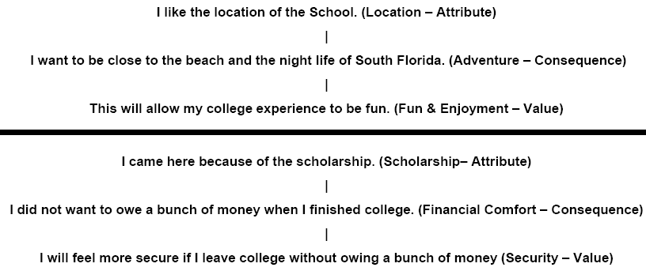

Research Goal

The present study sought to apply means-end theory to determine the attributes, consequences, and values that underpinned college selection for female student athletes at an NCAA Division II institution.

Method

*Procedure*

Semi-structured interviews were conducted with two researchers and individual student athletes. The participants were asked to recall the colleges that they seriously considered as they made their final college selection. Participants were then asked to list factors (attributes) that they relied on as they selected their college over their other finalists. The researchers then utilized the laddering technique as described by Reynolds and Gutman (1988) and later applied to student athletes and college selection by Klensoky, Templin, and Troutman (2001) to create means-end chains, in which each attribute was explored via the question, “Why is that important to you?” This would elicit a response suggesting how this attribute would benefit the participant (consequence). Then the “Why is that important to you?” question would be used to move the participant into deeper reflection, moving from the consequence to a personal value. Participants would create from two to four chains and interviews generally lasted ten to fifteen minutes.

To elicit the most thoughtful and honest answers possible, the researchers utilized the interview methods suggested by Reynolds & Gutman (1988). These included conducting interviews in a non threatening environment (a library area was used, which represented a more neutral site for participants than would a professor’s office or a classroom), making an effort to position the participant as the only expert regarding their college selection, with emphasis being placed on reassuring them that there was no right or wrong answer, and showing interest in responses while refraining from giving cues suggesting judgment. Following each interview, the researchers used interview notes to create means-end chains, which connected each attribute cited by the participants with the corresponding consequences and values stemming from it. Discrepancies were resolved jointly, relying as strictly as possible on key words and phrases used by the participants and recorded in the interview notes.

*Participants*

The participants in this study were 25 female student athletes at an NCAA Division II university in Florida during the 2005-2006 academic year. Participants represented a variety of sports, including basketball, soccer, softball, golf, tennis, rowing, and cross country.

Results

In total, 77 means-end chains were created, an average of 3.08 per participant. Coding of the means-end chains revealed eight attributes cited as important to the selection of the student athletes’ current college. These attributes led to eight potential consequences, which, in turn, led to four values.

Table 2

Summary of all attributes, consequences, and values identified throughout the interview process

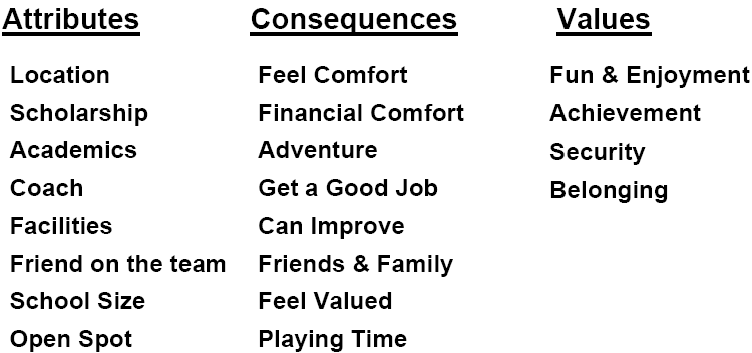